# HW 09 Wrangling II

Amanda Russom

```r
library(tidyverse)
```

```r
library(here)
```

```r
library(knitr)
```

```r
library(smatr)
```

### Source my_functions

```r
source(here("scripts","my_functions.R"))
```

### Import darters.csv and remove species tetrazonum and zonale

```r
darters_data <- read_csv(here("Data","darters.csv"))
darters_data_filtered <- darters_data %>%
  filter(species=="blennioides"|species=="caeruleum"|species=="spectabile")
```

### Sum majsub and minsub to form new column. Change riffle values. Change length units. Change sex values.

```r
wrangled_darters_data <- mutate(darters_data_filtered, total_substrate=majsub+minsub) %>%
  mutate(riffle=ifelse(riffle==1,
                       "Riffle 1",
                       "Riffle 2")) %>%
  mutate(length=length*10) %>%
  mutate(sex = ifelse(sex == "f",
                    "Female",
                    "Male"))
```

### Summarize the mean length, depth, and velocity. Group by species and riffle.

```r
spec_riffle_sep_wrang_darters_data <- group_by(wrangled_darters_data, species, riffle)
summary_wrangled_data <- summarize(spec_riffle_sep_wrang_darters_data, length=mean(length, na.rm=TRUE), depth=mean(depth, na.rm = TRUE),velocity=mean(velocity,na.rm = TRUE))
```

### Use kable to make a table

```r
kable(summary_wrangled_data)
```

| species | riffle | length | depth | velocity |
| --- | --- | --- | --- | --- |
| blennioides | Riffle 1 | 34.88889 | 23.600000 | 0.4110000 |
| blennioides | Riffle 2 | 37.36842 | 19.489474 | 0.4063158 |
| caeruleum | Riffle 1 | 35.58974 | 22.620513 | 0.4023077 |
| caeruleum | Riffle 2 | 28.07143 | 8.571429 | 0.3950000 |
| spectabile | Riffle 1 | 33.25926 | 15.596296 | 0.3740741 |
| spectabile | Riffle 2 | 29.10000 | 10.840000 | 0.3980000 |

#### Plot 1 summarized darters data

```
`fun.y` is deprecated. Use `fun` instead.`fun.ymin` is deprecated. Use `fun.min` instead.`fun.ymax` is deprecated. Use `fun.max` instead.
```

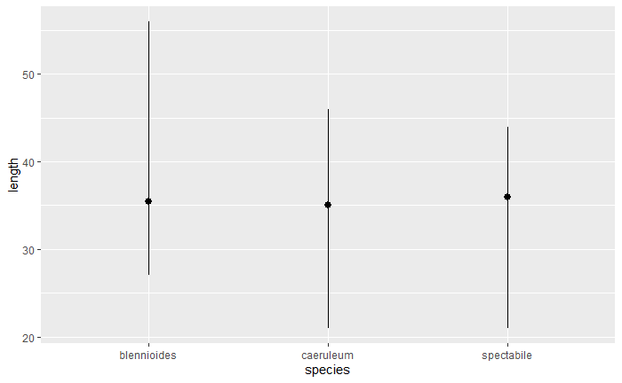

```r
ggplot(data = wrangled_darters_data) +
  stat_summary(
    mapping = aes(x = species, y = length),
    fun.ymin = min,
    fun.ymax = max,
    fun.y = median
  )
```

#### Add geom_point() to add mean length

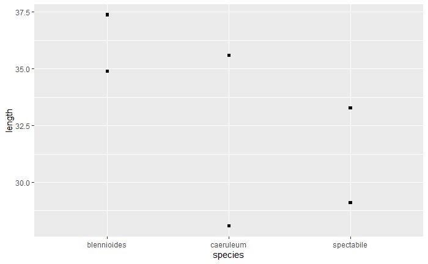

```r
 ggplot(data = summary_wrangled_data) +
  geom_point(mapping = aes(x=species, y=length), shape=15)
```

```r
stat_summary(
    fun.ymin = min,
    fun.ymax = max,
    fun.y = median
  )
```

```
`fun.y` is deprecated. Use `fun` instead.`fun.ymin` is deprecated. Use `fun.min` instead.`fun.ymax` is deprecated. Use `fun.max` instead.
```

```
geom_pointrange: na.rm = FALSE, orientation = NA
stat_summary: fun.data = NULL, fun = function (x, na.rm = FALSE, ...)
UseMethod("median"), fun.max = .Primitive("max"), fun.min = .Primitive("min"), fun.args = list(), na.rm = FALSE, orientation = NA
position_identity
```

### Rotate axis, seperate in to 2 riffle, add labs()

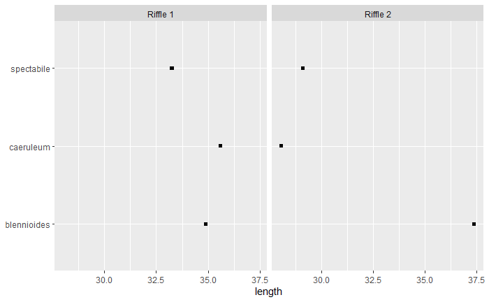

```r
ggplot(data = summary_wrangled_data) +
  geom_point(mapping = aes(x=species, y=length), shape=15)+
  facet_wrap(~ riffle) +
  coord_flip() +
  labs(y = "length", x = NULL)
```

```r
stat_summary(
    fun.ymin = min,
    fun.ymax = max,
    fun.y = median
  )
```

```
`fun.y` is deprecated. Use `fun` instead.`fun.ymin` is deprecated. Use `fun.min` instead.`fun.ymax` is deprecated. Use `fun.max` instead.
```

```
geom_pointrange: na.rm = FALSE, orientation = NA
stat_summary: fun.data = NULL, fun = function (x, na.rm = FALSE, ...)
UseMethod("median"), fun.max = .Primitive("max"), fun.min = .Primitive("min"), fun.args = list(), na.rm = FALSE, orientation = NA
position_identity
```

# riffle 2 contains the longest average blennioides, but among the other species, the individuals in riffle one are longer

### darters plot 2

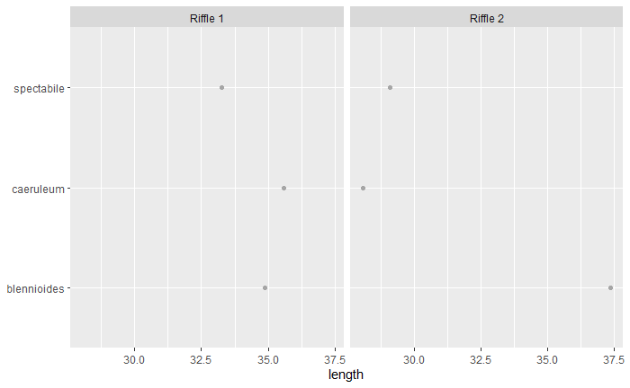

```r
ggplot(data = summary_wrangled_data) +
  geom_point(mapping = aes(x=species, y=length), color= "gray65")+
  facet_wrap(~ riffle) +
  coord_flip() +
  labs(y = "length", x = NULL)
```

```r
stat_summary(
    fun.y = median,
    geom = "point",
    size = 2.2
  )
```

```
`fun.y` is deprecated. Use `fun` instead.
```

```
geom_point: na.rm = FALSE
stat_summary: fun.data = NULL, fun = function (x, na.rm = FALSE, ...)
UseMethod("median"), fun.max = NULL, fun.min = NULL, fun.args = list(), na.rm = FALSE, orientation = NA
position_identity
```

### darters plot2, added second stat_summary function to graph

```
`fun.y` is deprecated. Use `fun` instead.`fun.y` is deprecated. Use `fun` instead.
```

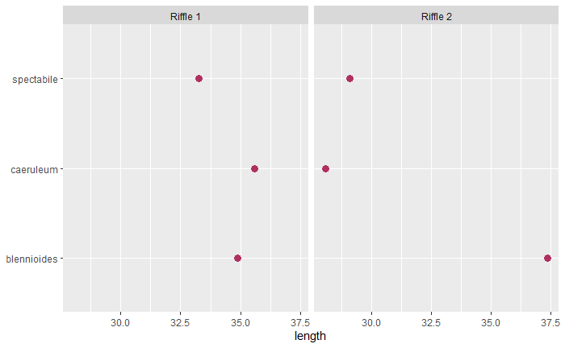

```r
ggplot(data = summary_wrangled_data, aes(x= species, y= length))+
  geom_point(color= "gray65")+
stat_summary(
    fun.y = median,
    geom = "point",
    size = 2.2) +
stat_summary(
    fun.y = mean,
    geom = "point",
    size = 3,
    color = "maroon")+
  facet_wrap(~ riffle) +
  coord_flip() +
  labs(y = "length", x = NULL)
```

```r
NA
NA
NA
```

```r
library(tidyverse)
library(smatr)
```

### load feathers data and remove decimal commas

```r
feathers_data <- read_csv(here("Data","feathers.csv"),locale = locale(decimal_mark = ",") )
```

### Renaming feather columns

```r
feathers_data_2 <- feathers_data %>%
  rename("capture_date" = "Capture Date", "day" = "Date","site"= "Site","urban_score"=  "Urba Score","cortF"="CortF ng/mg", "cortB"="CortF ng/mm", "sex"="Sex", "smi"="SMI", "tarsus"="Tarsus", "mass"="Mass", "basal_cort" = "Bas_Cort", "stress_cort" ="Stress_Cort")
```

### calculate the mean tarsus length, store in mean_tarsus

```r
mean_tarsus <- mean(feathers_data_2$tarsus, na.rm = TRUE)
```

### Use mutate () to form new columns

```r
mutated_feathers_data_2 <- mutate(feathers_data_2,log_mass=log(mass),log_tarsus=log(tarsus))
```

### use sma() function to calculate the standardized major axis regression

```r
major_axis <- sma(log_mass ~ log_tarsus, data = mutated_feathers_data_2)
```

### apply summary function

```r
summary(major_axis)
```

```
Call: sma(formula = log_mass ~ log_tarsus, data = mutated_feathers_data_2)

Fit using Standardized Major Axis

------------------------------------------------------------
Coefficients:
             elevation    slope
estimate    -2.2061196 1.864889
lower limit -3.5801826 1.450317
upper limit -0.8320566 2.397966

H0 : variables uncorrelated
R-squared : 0.3510553
P-value : 2.8406e-05
```

### apply coef() function

```r
coef(major_axis)
```

```
elevation     slope
-2.206120  1.864889
```

### store slope value in b

```r
slope <- coef(major_axis)
b <- slope['slope']
```

### use mutate to add new SMI column

```r
feathers_data_2_w_SMI <- mutate(feathers_data_2,new_smi = scaled_mass(mass,tarsus,b))
```

#### compare new columns

```r
select(feathers_data_2_w_SMI, "smi", "new_smi")
```

| smi | new_smi |
| --- | --- |
| 26.1 | 26.10524 |
| 24.5 | 24.47756 |
| 25.1 | 25.12752 |
| 26.6 | 26.58630 |
| 23.9 | 23.84877 |
| 24.2 | 24.14813 |
| 26.5 | 26.51466 |
| 23.7 | 23.67004 |
| 25.8 | 25.84271 |
| 25.7 | 25.70813 |

[output cut: 33 more lines]

### Group by site

```r
site_sorted_feathers_data <- group_by(feathers_data_2_w_SMI,site)
```

### calculate the mean and standard error of the mean

```r
summarized_feathers_data <- summarise(site_sorted_feathers_data, basal_mean=mean(basal_cort, na.rm = TRUE),stress_mean = mean(stress_cort, na.rm=TRUE), std_err_basal=std_err(basal_cort, na.rm=TRUE),std_err_cort=std_err(stress_cort, na.rm=TRUE))
```

### print results

```r
summarized_feathers_data
```

| site | basal_mean | stress_mean | std_err_basal | std_err_cort |
| --- | --- | --- | --- | --- |
| CEBC | 1.108000 | 23.71455 | 0.3065319 | 1.831102 |
| LAROCHELLE | 1.731818 | 21.57923 | 0.5045463 | 1.756890 |
| NIORT | 2.160000 | 15.62800 | 0.7393691 | 1.454544 |
| VILLEFOLLET | 1.176667 | 16.95667 | 0.2893633 | 2.217938 |

### Plot 1 of feathers data

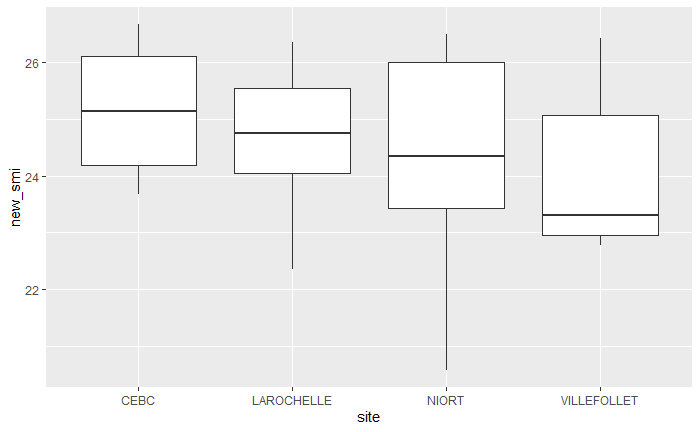

```r
ggplot(data=site_sorted_feathers_data)+
  geom_boxplot(mapping=aes(x=site,y=new_smi))
```

### The individuals of the niort site have much wider range of smi vaules as compared to the other sites

### Plot 2 feathers data

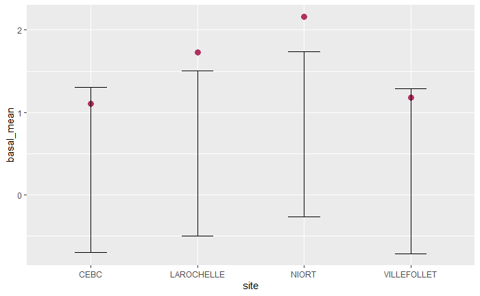

```r
ggplot(data=summarized_feathers_data)+
  geom_point(mapping=aes(x=site,y=basal_mean),size=3, color ="maroon", fill= "maroon")+
  geom_errorbar(aes(x=site, ymin=std_err_basal-1,ymax=std_err_basal+1),width = .3)
```

### the assignment wanted us to plot the basal cortico concetration for each site, I hope this only meant the mean vaule and not all the collected vaules, because that’s what we did :/

### Plot 3 feathers data

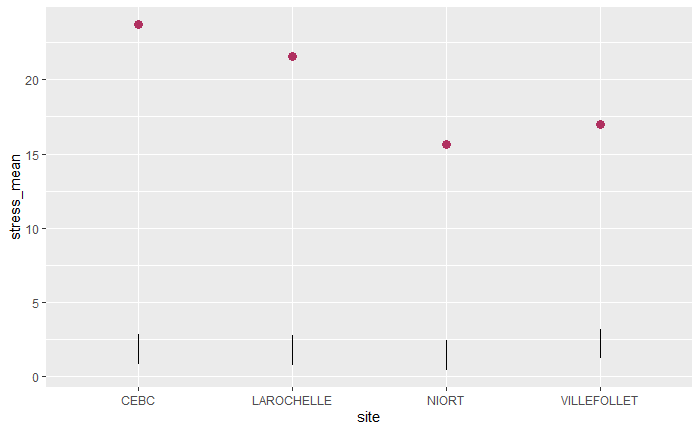

```r
ggplot(data=summarized_feathers_data)+
  geom_point(mapping=aes(x=site,y=stress_mean),size=3, color ="maroon")+
  geom_linerange(mapping = aes(x=site,ymin=std_err_cort-1,ymax=std_err_cort+1))
```

### I am starting to doubt my functions were written correctly… why is the standard error of the mean so far from the mean vaules? :(

### I completed the graduate requirements on plot 2 of the feathers data, However, I could not figure out how to get the line to pass behind the dots. I tried using the aesthetics linetyp and alpha, but these only broke the line of diminished the line color.